# R Notebook

```r
library(tidyverse)
library(janitor)
library(dplyr)
library(cluster)
library(factoextra)
library(dendextend)
```

```r
computers <- read_csv("data/computers.csv")
```

```r
#This data does look potentially good for clustering but will need more investigation
head(computers)
```

| X1 | price | speed | hd | ram | screen | cd | multi | premium | ads | trend |
| --- | --- | --- | --- | --- | --- | --- | --- | --- | --- | --- |
| 1 | 1499 | 25 | 80 | 4 | 14 | no | no | yes | 94 | 1 |
| 2 | 1795 | 33 | 85 | 2 | 14 | no | no | yes | 94 | 1 |
| 3 | 1595 | 25 | 170 | 4 | 15 | no | no | yes | 94 | 1 |
| 4 | 1849 | 25 | 170 | 8 | 14 | no | no | no | 94 | 1 |
| 5 | 3295 | 33 | 340 | 16 | 14 | no | no | yes | 94 | 1 |
| 6 | 3695 | 66 | 340 | 16 | 14 | no | no | yes | 94 | 1 |

```r
dim(computers)
```

```
[1] 6259   11
```

```r
class(computers)
```

```
[1] "spec_tbl_df" "tbl_df"      "tbl"         "data.frame"
```

```r
any(is.na(computers))
```

```
[1] FALSE
```

```r
#standardising the data

computers1 <- computers %>%
  clean_names()
```

```r
computers1 <- computers %>%
    select(hd, ram)

head(computers1)
```

| hd | ram |
| --- | --- |
| 80 | 4 |
| 85 | 2 |
| 170 | 4 |
| 170 | 8 |
| 340 | 16 |
| 340 | 16 |

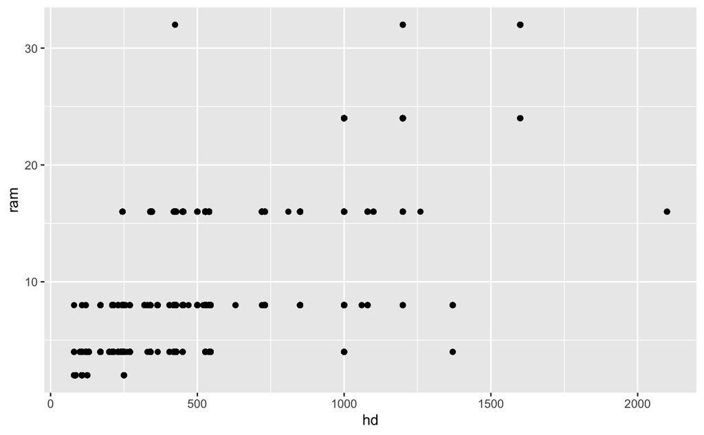

```r
ggplot(computers1, aes(hd, ram)) +
  geom_point()
```

```r
summary(computers1)
```

```
       hd              ram
 Min.   :  80.0   Min.   : 2.000
 1st Qu.: 214.0   1st Qu.: 4.000
 Median : 340.0   Median : 8.000
 Mean   : 416.6   Mean   : 8.287
 3rd Qu.: 528.0   3rd Qu.: 8.000
 Max.   :2100.0   Max.   :32.000
```

```r
computers1_scale <- computers1 %>%
                    mutate_all(scale)

computers1_scale
```

| hd | ram |
| --- | --- |
| -1.30189023 | -0.76129843 |
| -1.28255149 | -1.11646890 |
| -0.95379299 | -0.76129843 |
| -0.95379299 | -0.05095751 |
| -0.29627598 | 1.36972433 |
| -0.29627598 | 1.36972433 |
| -0.95379299 | -0.76129843 |
| -1.28255149 | -1.11646890 |
| -0.79908310 | -0.05095751 |
| -0.79908310 | -0.76129843 |

[output cut: 990 more lines]

```r
library(broom)
clustered_computers <- kmeans(computers1_scale, centers = 6, nstart = 25)
```

```r
tidy(clustered_computers,
     col.names = colnames(computers1_scale))
```

| hd | ram | size | withinss | cluster |
| --- | --- | --- | --- | --- |
| -0.4850999 | -0.05095751 | 745 | 36.02784 | 1 |
| 0.4603185 | 1.36972433 | 821 | 168.14783 | 2 |
| 0.2722738 | -0.15975973 | 1704 | 250.29368 | 3 |
| 2.0993943 | 0.69997432 | 315 | 246.58534 | 4 |
| 2.5345722 | 2.84885195 | 316 | 189.37178 | 5 |
| -0.8238806 | -0.82064414 | 2358 | 238.32650 | 6 |

```r
glance(clustered_computers)
```

| totss | tot.withinss | betweenss | iter |
| --- | --- | --- | --- |
| 12516 | 1128.753 | 11387.25 | 2 |

```r
NA
```

```r
augment(clustered_computers, computers1)
```

| hd | ram | .cluster |
| --- | --- | --- |
| 80 | 4 | 6 |
| 85 | 2 | 6 |
| 170 | 4 | 6 |
| 170 | 8 | 1 |
| 340 | 16 | 2 |
| 340 | 16 | 2 |
| 170 | 4 | 6 |
| 85 | 2 | 6 |
| 210 | 8 | 1 |
| 210 | 4 | 6 |

[output cut: 990 more lines]

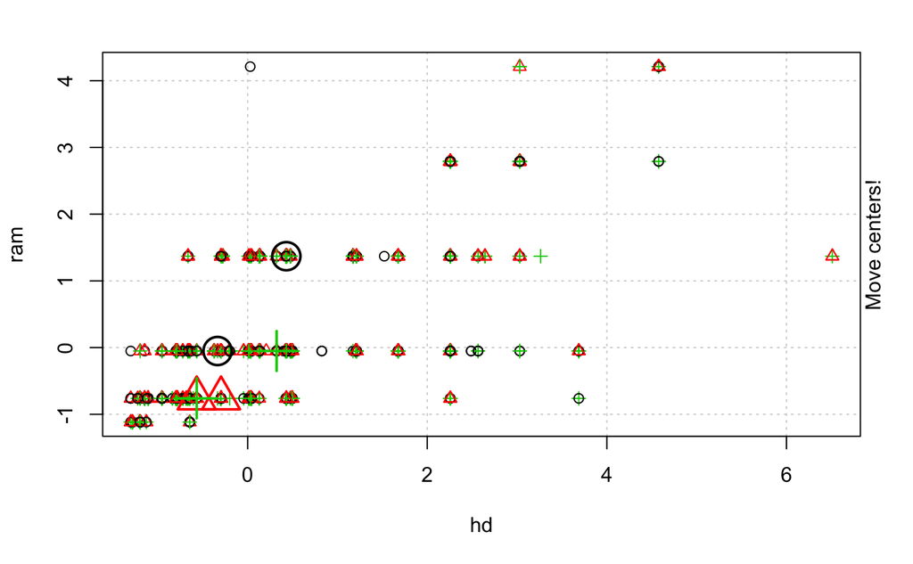

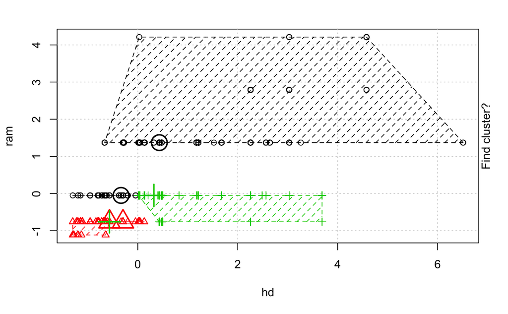

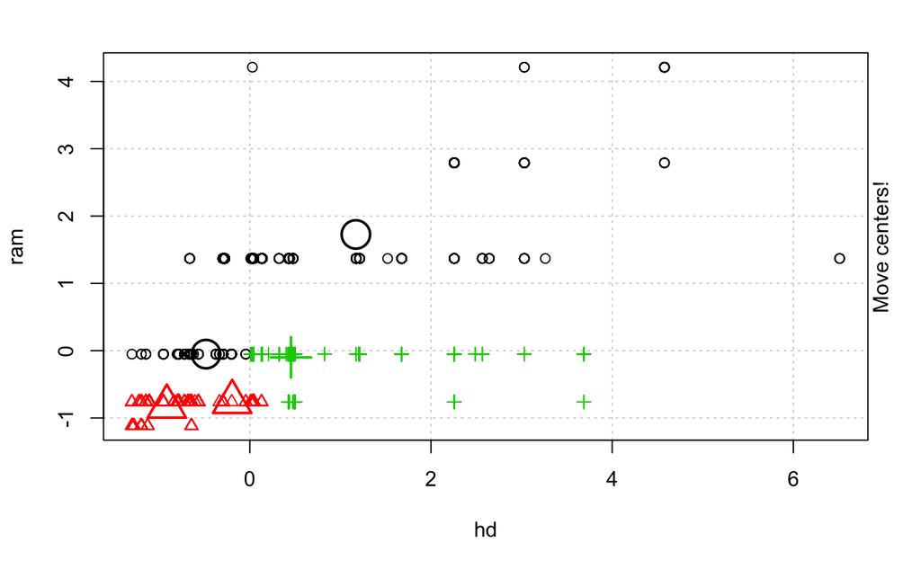

[figure not shown]

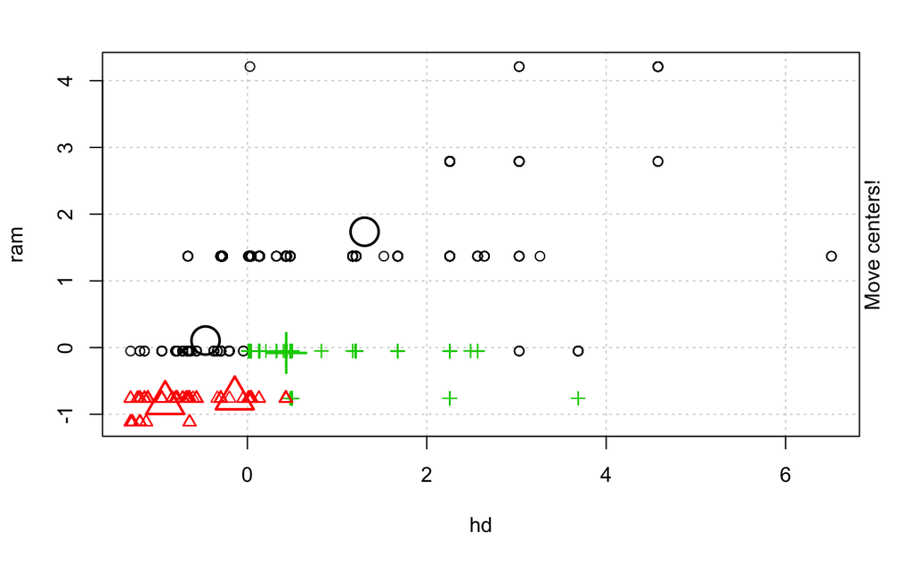

[figure not shown]

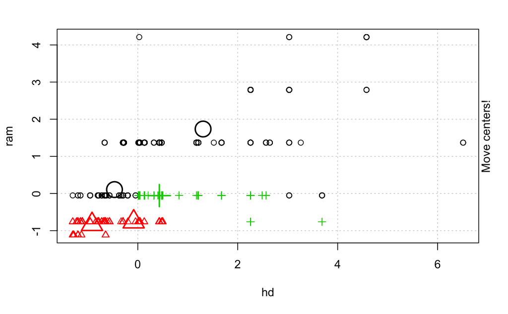

[output not shown]

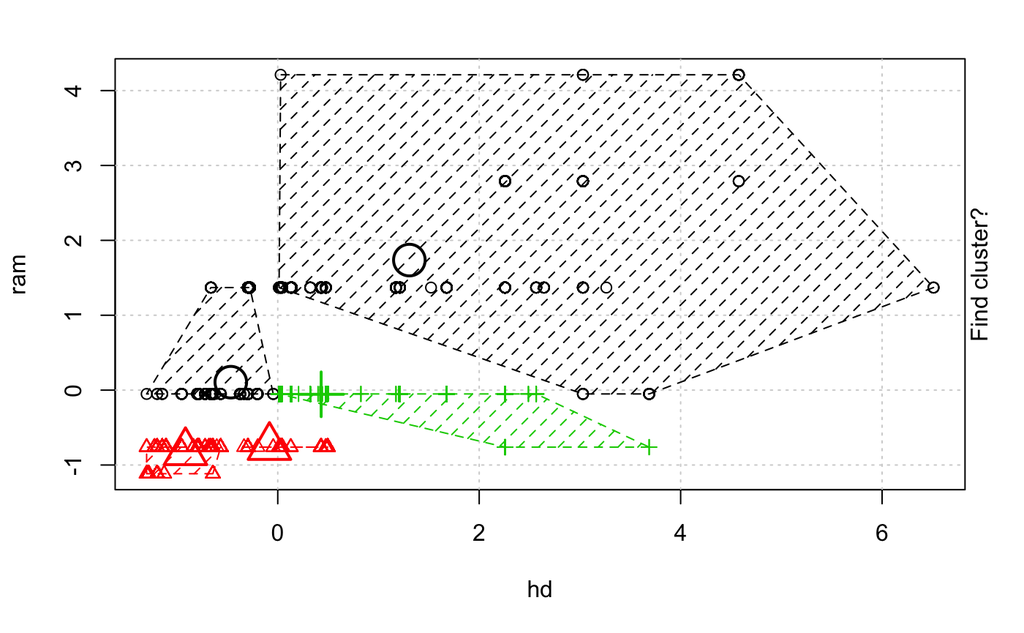

```r
library(animation)

computers1_scale %>%
  kmeans.ani(centers = 6)
```

```r
glance(clustered_computers)
```

[output not shown]

```r
max_k <- 20

k_clusters <- tibble(k = 1:max_k) %>%
  mutate(
    kclust = map(k, ~ kmeans(computers1_scale, .x, nstart = 25)),
    tidied = map(kclust, tidy),
    glanced = map(kclust, glance),
    augmented = map(kclust, augment, computers1)
  )

k_clusters
```

| k | kclust | tidied | glanced | augmented |
| --- | --- | --- | --- | --- |
| 1 |  |  |  |  |
| 2 |  |  |  |  |
| 3 |  |  |  |  |
| 4 |  |  |  |  |
| 5 |  |  |  |  |
| 6 |  |  |  |  |
| 7 |  |  |  |  |
| 8 |  |  |  |  |
| 9 |  |  |  |  |
| 10 |  |  |  |  |

[output cut: 10 more lines]

```r
library(factoextra)
```

```r
fviz_nbclust(computers1_scale, kmeans, method = "wss", nstart = 25)
```

[output not shown]

```r
fviz_nbclust(computers1_scale, kmeans, method = "silhouette", nstart = 25)
```

[output not shown]

```r
fviz_nbclust(computers1_scale, kmeans, method = "gap_stat", nstart = 25, k.max = 10)
```

[output not shown]

```r
 clusterings %>%
  unnest(cols = c(augmented)) %>%
  filter(k <= 6) %>%
 ggplot(aes(x = hd, y = ram)) +
  geom_point(aes(color = .cluster)) +
  facet_wrap(~ k)
```

[output not shown]

```r
clusterings %>%
  unnest(augmented) %>%
  filter(k == 2) %>%
  group_by(.cluster) %>%
  summarise(mean(hd), mean(ram))
```

[output not shown]

CODECLAN SOLUTION

```r
library(janitor)
library(fastDummies)
library(broom)
library(rpart)
library(rpart.plot)
library(tidyverse)
library(factoextra)
```

```r
pc_sales <- read_csv("data/computers.csv")
```

```r
head(pc_sales)
```

| X1 | price | speed | hd | ram | screen | cd | multi | premium | ads | trend |
| --- | --- | --- | --- | --- | --- | --- | --- | --- | --- | --- |
| 1 | 1499 | 25 | 80 | 4 | 14 | no | no | yes | 94 | 1 |
| 2 | 1795 | 33 | 85 | 2 | 14 | no | no | yes | 94 | 1 |
| 3 | 1595 | 25 | 170 | 4 | 15 | no | no | yes | 94 | 1 |
| 4 | 1849 | 25 | 170 | 8 | 14 | no | no | no | 94 | 1 |
| 5 | 3295 | 33 | 340 | 16 | 14 | no | no | yes | 94 | 1 |
| 6 | 3695 | 66 | 340 | 16 | 14 | no | no | yes | 94 | 1 |

Select hd and ram variables and visualise

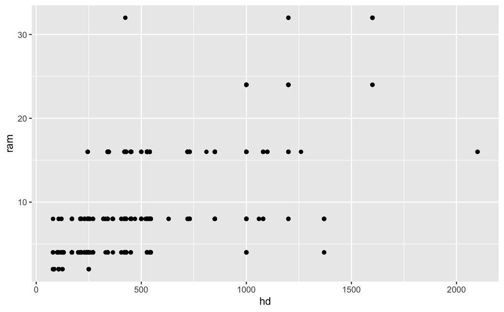

```r
pc_sales <- pc_sales %>%
  select(c(hd, ram))

ggplot(pc_sales, aes(hd, ram)) +
  geom_point()
```

There is some dispersion in the data but perhaps not very clear circular groups of points (i.e. heterogeneous clusters). But let’s give it a go to see what we get!

Scale and check.

```r
pc_sales_scale <- pc_sales %>%
                      mutate_all(scale)

summary(pc_sales_scale)
```

```
        hd.V1              ram.V1
 Min.   :-1.301890   Min.   :-1.116469
 1st Qu.:-0.783612   1st Qu.:-0.761298
 Median :-0.296276   Median :-0.050958
 Mean   : 0.000000   Mean   : 0.000000
 3rd Qu.: 0.430860   3rd Qu.:-0.050958
 Max.   : 6.510959   Max.   : 4.211088
```

Check each of the methods of choosing k:

```r
library(factoextra)
```

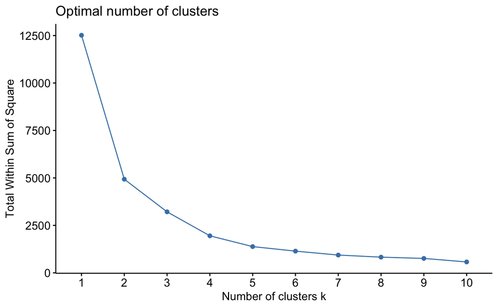

```r
fviz_nbclust(pc_sales_scale, kmeans, method = "wss", nstart = 25)
```

This graph is fairly smooth curve - rather than a defined kink. Some arguement that kink at k = 2 or k = 4.

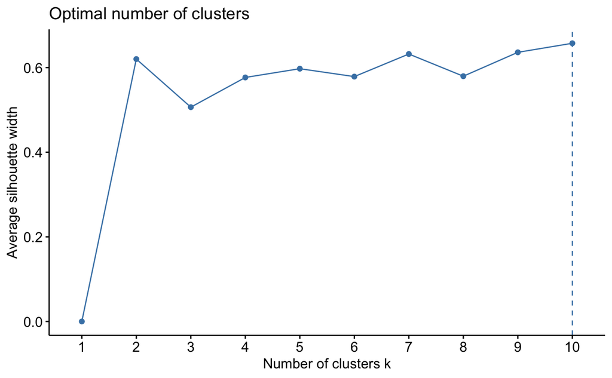

```r
fviz_nbclust(pc_sales_scale, kmeans, method = "silhouette", nstart = 25)
```

Silhouette method is giving k = 10 but the values for k = 2,7,9 are very close to the silhouette width, so very close margin that k=10 has been picked as optimal.

[output not shown]

[output not shown]

[output not shown]

[output not shown]

[output not shown]

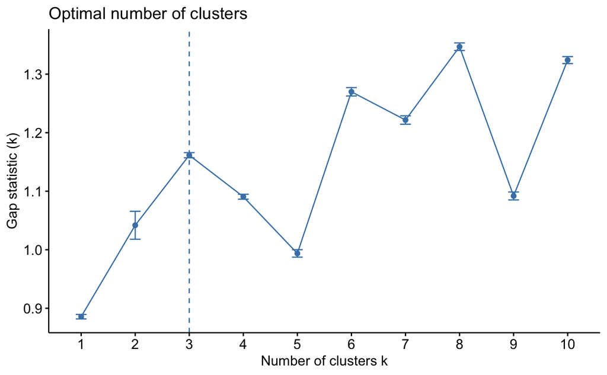

```r
fviz_nbclust(pc_sales_scale, kmeans, method = "gap_stat") #would put nstart=25 if had more computing power
```

This gives a result of k = 3.

We get quite different results for each of the methods and for elbow and silhouette many values of k give quite similar results. This can be a sign data is not well suited for k-means clustering.

From the elbow method and the silhouette coefficient going to go for k=2.

```r
clustered_pc_sales <- kmeans(pc_sales_scale, 2, nstart = 25)

clustered_pc_sales
```

[output not shown]

Pull out the cluster means and sizes for your chosen number of clusters.

```r
clustered_pc_sales$size
```

```
[1] 1515 4744
```

```r
clustered_pc_sales$centers
```

```
         hd        ram
1  1.277295  1.4705318
2 -0.407905 -0.4696154
```

Visualise the clusters.

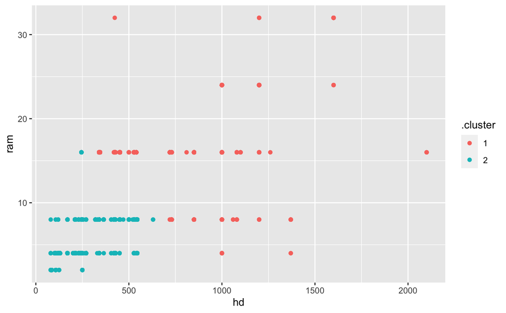

```r
clusters <- augment(clustered_pc_sales, pc_sales)

ggplot(clusters, aes(x = hd, y = ram, colour = .cluster)) +
  geom_point()
```

Comment on the results:

Judging from the visualisation the points within cluster 1 are very different - RAM ranges from 4 to 32 and HD ranges from 340 to 2,100 (both almost as wide as the full spread of the dataset). So it doesn’t seem like the computers within cluster 1 are particularly similar in attributes e.g. say we were using clustering to find groups of similar computers to create a new product for - the product would need to cater for pretty much any of the computer in the dataset rather than target a subgroup which had similar ram/hd levels.

Would potentially try other values of k or may look into a different type of clustering for this data.